# Project 5: Explore and Summarize Data

# Multivariate Plots Section

In this section, I will be looking at two features that help wine reach it’s best quality ratings.

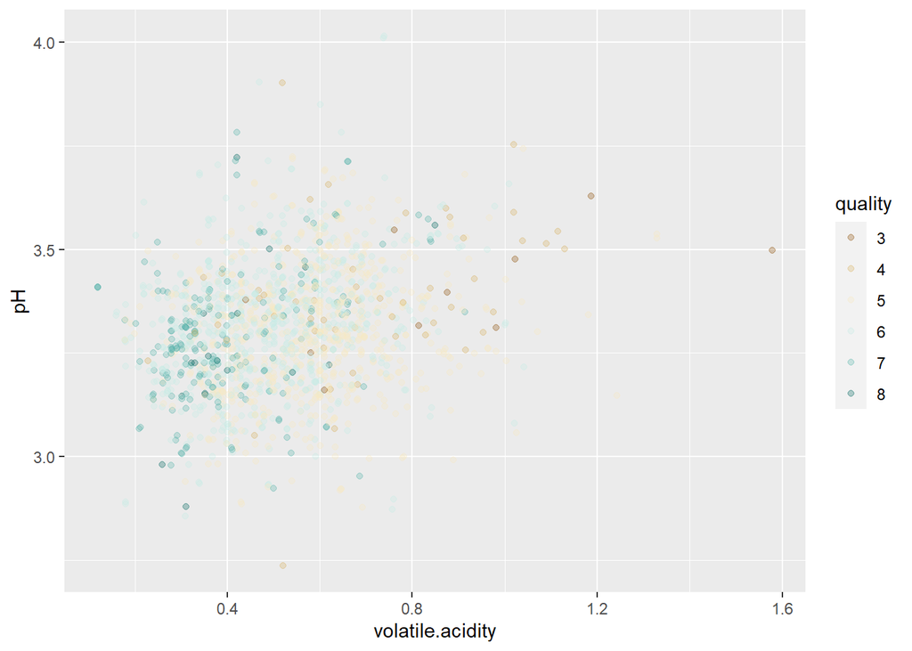

High quality wines contain low volatile acidity and low pH levels.

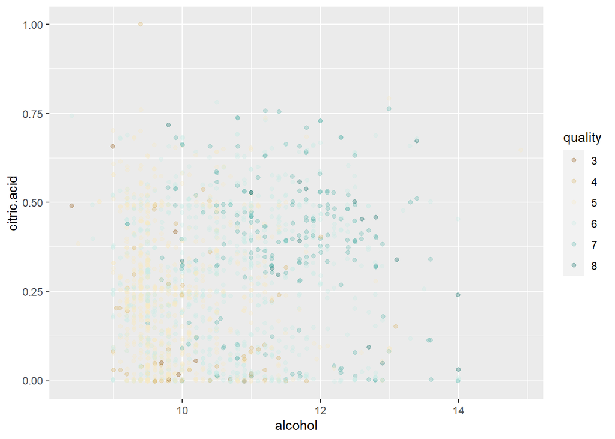

High quality wines contain a high citric acid level and high alcohol content.

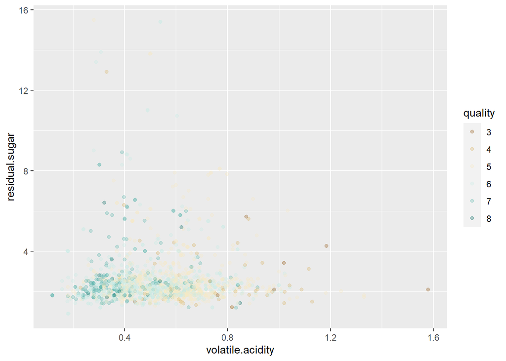

High quality wines have a low residual sugars amount and a low volatile acidity level.

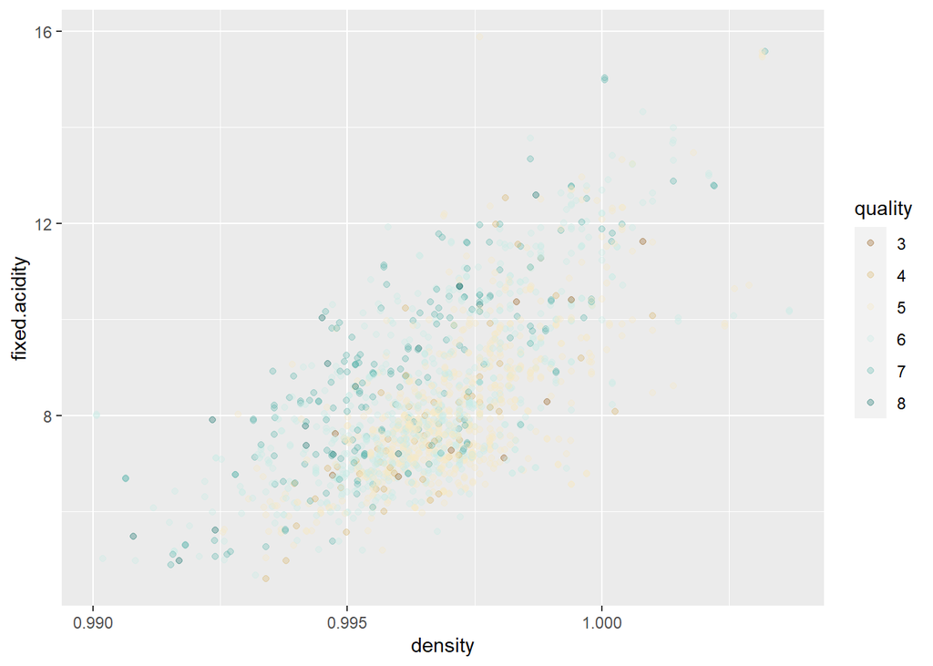

High quality wines have a higher fixed acidity level and a lower density level.

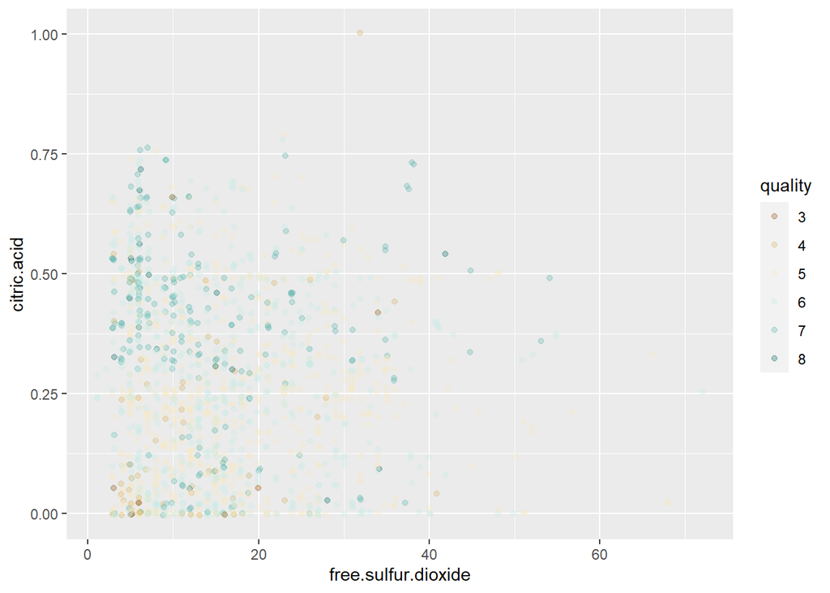

High quality wines have a low sulfur dioxide count and a high citric acid level.

I believe what most of these comparisons are showing is that if there is more alcohol content and that wine content is created from a large amount of citric acids (acid sucrose supplements), then the wine will be perceived as better.

# Multivariate Analysis

**Talk about some of the relationships you observed in this part of the investigation. Were there features that strengthened each other in terms of looking at your feature(s) of interest?**

The features that strengthened each other were to have a low volatile acidity count and a high citric acid level which led to a more alcoholic fruity wine.

**Were there any interesting or surprising interactions between features?**

Nothing too surprising. Quality comes down to citric acid levels being high which causes volatile acidity to be low. This plus having a less dense wine that is more alcoholic will prove to be a quality wine.

**OPTIONAL: Did you create any models with your dataset? Discuss the strengths and limitations of your model.**

No.

# Final Plots and Summary

### Plot One

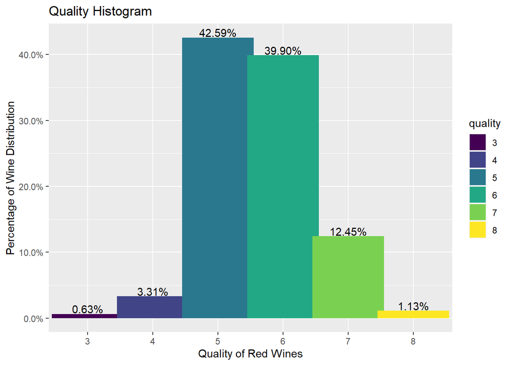

I chose this quality histogram because the feature of quality stood out against the other more scientifically measured variables. **Quality** became more of a result of the combination of features from the wine itself. In this histogram, we can get a better breakdown of where each wine specifically falls into each quality rating. Most wines are right in the middle of the quality scale at 5, while the top rated wines are very rare at 1.13%.

### Plot Two

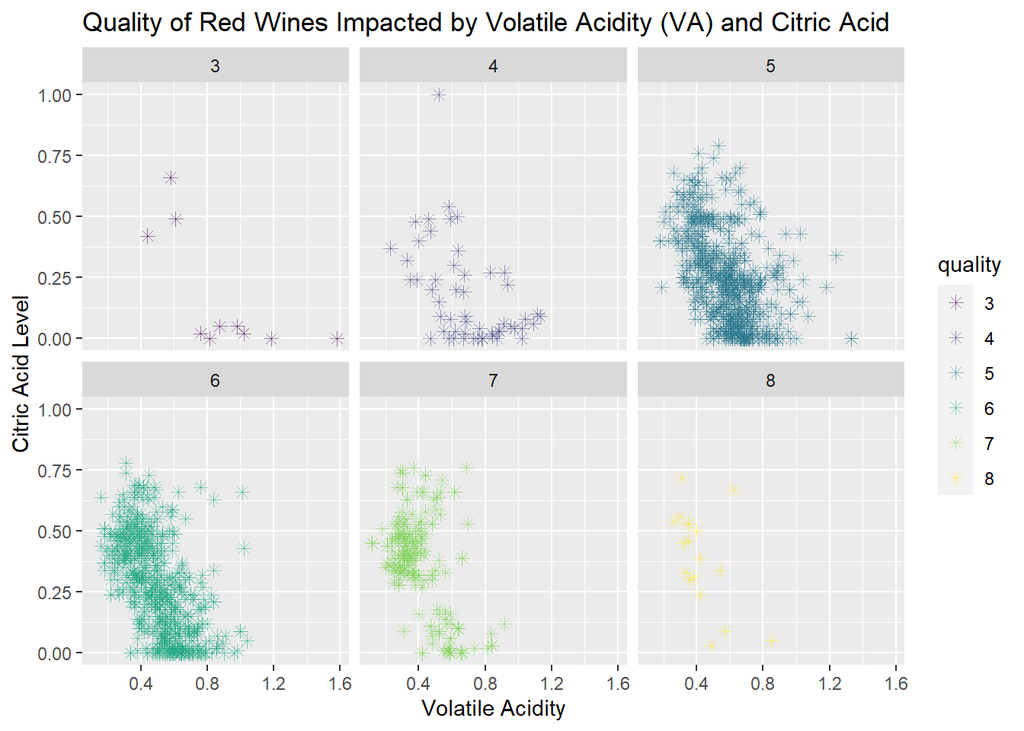

I chose this plot because both factors had some of the highest positive and negative correlations with the quality of the wine. **Volatile Acidity** is considered undesireable in red wines and it shows on this comparison against our **Quality** factor. While it is not valued as much, some of it is still necessary for the overall flavor of wine. Remove it altogether and I predict the quality of wine would decrease as well. On the counterpoint, **Citric Acid** is a sought after ingredient in quality wines. The higher the alcohol from citric acid, the more desireable the wine. Although wines of the past used citric acid from fruits direcly, modern day wines use fermented sucrose solutions to save cost and still give the same effect to wine drinkers.

### Plot Three

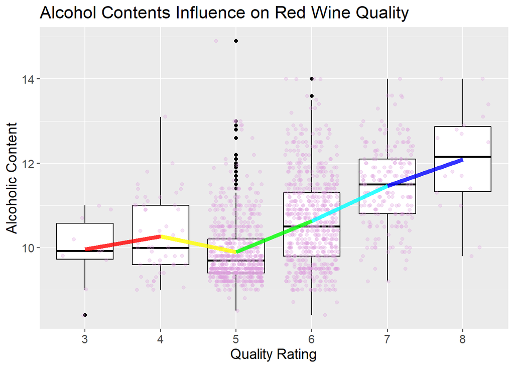

**Alcohol** was also one of the largest factors in determining a high wine quality. This goes hand in hand with citric acid in that the more alcohol from citric acid the higher the wine quality. In this plot we can determine that the highest quality wines are also hold above average percentages of alcohol. Does this mean that if you purchase a wine with higher alcoholic content it will be better? Probably, but make sure it’s sweeter too.

# Reflection

This exploration of data using R was my first time even using the R language. I found myself constantly comparing it to analysing data using Python. I found lots to like though in R, from the easy way to load new packages, to the overflowing amount of graphing types and customization. I can see why this still can be considered the language of choice for analysis.

As for the dataset itself, I found it challenging in that I’m not much of a wine drinker. So to me, I had a hard time relating to what would make a good wine. I learned a lot about the different factors and how they affect overall quality from this dataset. I felt that this dataset was a bit skewed towards quality though as it was the only sensory variable out of the set. The others were all based on their chemical influence on wine.

Things I would continue to find in this set, would be subsetting a lot of the data and remove outliers to clean up some of the plots I made. Probably applying more statistical analysis as well. These plots look nice but sometimes it’s good to have a nice table of data for study. I would find some xtable library examples out there on the ’net to make even the tables look nice.